# Early C2C12 Growth

Dr. Sara J. Smith

14 September, 2026

## **Load Libraries & Data**

Load necessary libraries and data, clean and refactor data.

## **Myogenin Expression**

### *Modelling*

```r
myo.mod <- lmer(deltacq ~ condition*day + (1|trial), data = myo)
```

```
## fixed-effect model matrix is rank deficient so dropping 3 columns / coefficients
```

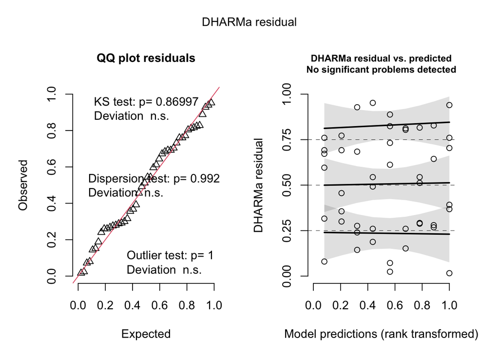

```r
myo.res <- simulateResiduals(myo.mod)
plot(myo.res)
```

```r
summary(myo.mod)
```

```
## Linear mixed model fit by REML. t-tests use Satterthwaite's method [
## lmerModLmerTest]
## Formula: deltacq ~ condition * day + (1 | trial)
##    Data: myo
##
## REML criterion at convergence: 127.6
##
## Scaled residuals:
##      Min       1Q   Median       3Q      Max
## -1.95672 -0.57724 -0.00758  0.63637  1.60073
##
## Random effects:
##  Groups   Name        Variance Std.Dev.
##  trial    (Intercept) 1.1800   1.0863
##  Residual             0.9043   0.9509
## Number of obs: 46, groups:  trial, 6
##
## Fixed effects:
##                    Estimate Std. Error      df t value Pr(>|t|)
## (Intercept)          9.9761     0.5894 11.9938  16.926 9.76e-10 ***
## condition10HS        1.6197     0.5805 32.1359   2.790  0.00878 **
## condition2FBS        1.7516     0.5793 32.0704   3.024  0.00489 **
## condition2HS         1.3537     0.5805 32.1359   2.332  0.02612 *
## day1                -4.2556     0.5490 31.9806  -7.751 7.75e-09 ***
## day2                -6.3844     0.5490 31.9806 -11.629 5.04e-13 ***
## condition10HS:day1   1.2158     0.8451 32.0383   1.439  0.15996
## condition2FBS:day1  -0.1254     0.8452 32.0422  -0.148  0.88294
## condition2HS:day1    1.0471     0.8143 31.9806   1.286  0.20772
## ---
## Signif. codes:  0 '***' 0.001 '**' 0.01 '*' 0.05 '.' 0.1 ' ' 1
##
## Correlation of Fixed Effects:
##             (Intr) cn10HS cn2FBS cnd2HS day1   day2   c10HS: c2FBS:
## conditn10HS  0.000
## conditn2FBS  0.000  0.444
## conditin2HS  0.000  0.463  0.444
## day1        -0.466  0.000  0.000  0.000
## day2        -0.466 -0.473 -0.474 -0.473  0.500
## cndtn10HS:1  0.000 -0.676 -0.310 -0.307 -0.325  0.325
## cndtn2FBS:1  0.000 -0.311 -0.677 -0.311 -0.325  0.325  0.430
## cndtn2HS:d1  0.000 -0.319 -0.319 -0.701 -0.337  0.337  0.438  0.438
## fit warnings:
## fixed-effect model matrix is rank deficient so dropping 3 columns / coefficients
```

- Intercept: Represents the predicted deltacq value for the 10FBS condition at Day MB
- Condition effects (at Day MB): Compared to 10FBS at the MB time point, `deltacq` is significantly higher across all other media
- Day effects (in 10FBS): Relative to Day MB, `deltacq` significantly decreases over time within the baseline 10FBS condition
- Condition * Day interactions: None of the `condition:day1` interaction terms are strong. This indicates that the change in `deltacq` from Day MB to Day 1 in 10HS, 2FBS, and 2HS is not meaningfully different from the drop observed in 10FBS.
- All condition:day2 terms were automatically dropped because of the model matrix rank deficiency. Model is built in order of Intercept, Main Effects, then Interactions, which “uses up” all available degrees of freedom before getting to day 2 in interaction terms

Let’s try a model without MB to capture a full factorial design:

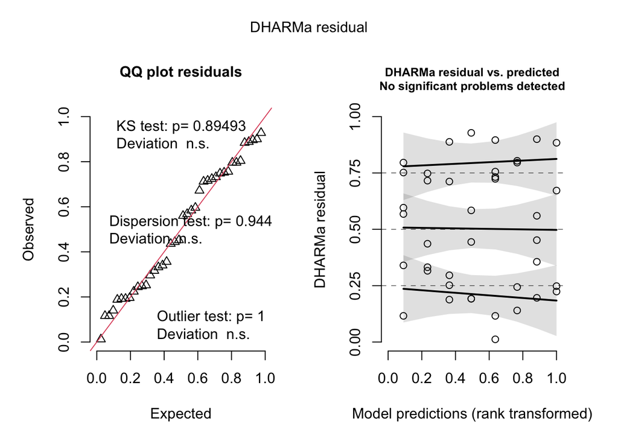

```r
myo.diff <- myo %>%
  filter(day == "1" | day == "2")

myo.diff.mod <- lmer(deltacq ~ condition * day + (1 | trial), data = myo.diff)
myo.diff.res <- simulateResiduals(myo.diff.mod)
plot(myo.diff.res)
```

```r
summary(myo.diff.mod)
```

```
## Linear mixed model fit by REML. t-tests use Satterthwaite's method [
## lmerModLmerTest]
## Formula: deltacq ~ condition * day + (1 | trial)
##    Data: myo.diff
##
## REML criterion at convergence: 108.5
##
## Scaled residuals:
##      Min       1Q   Median       3Q      Max
## -1.90323 -0.64750  0.00426  0.68358  1.44599
##
## Random effects:
##  Groups   Name        Variance Std.Dev.
##  trial    (Intercept) 1.331    1.1536
##  Residual             0.796    0.8922
## Number of obs: 40, groups:  trial, 6
##
## Fixed effects:
##                    Estimate Std. Error      df t value Pr(>|t|)
## (Intercept)          5.7206     0.5954 10.1820   9.608 2.00e-06 ***
## condition10HS        2.8215     0.5861 27.2337   4.814 4.92e-05 ***
## condition2FBS        1.5789     0.5851 27.1938   2.699 0.011823 *
## condition2HS         2.4056     0.5458 27.1696   4.408 0.000148 ***
## day2                -2.1289     0.5151 27.0084  -4.133 0.000311 ***
## condition10HS:day2  -1.1970     0.7935 27.0606  -1.508 0.143019
## condition2FBS:day2   0.1509     0.7936 27.0654   0.190 0.850652
## condition2HS:day2   -1.0471     0.7640 27.0084  -1.370 0.181822
## ---
## Signif. codes:  0 '***' 0.001 '**' 0.01 '*' 0.05 '.' 0.1 ' ' 1
##
## Correlation of Fixed Effects:
##             (Intr) cn10HS cn2FBS cnd2HS day2   c10HS: c2FBS:
## conditn10HS -0.380
## conditn2FBS -0.381  0.389
## conditin2HS -0.408  0.433  0.404
## day2        -0.433  0.439  0.440  0.472
## cndtn10HS:2  0.281 -0.726 -0.295 -0.306 -0.649
## cndtn2FBS:2  0.281 -0.293 -0.728 -0.302 -0.649  0.431
## cndtn2HS:d2  0.292 -0.296 -0.297 -0.700 -0.674  0.438  0.438
```

- Intercept: Represents the baseline predicted deltacq for 10FBS on Day 1.
- Day 1 Condition effects: On Day 1, all test conditions show significantly higher `deltacq` values compared to the baseline 10FBS
- Time (day 1 to day 2): In the 10FBS baseline condition, `deltacq` significantly decreases by 2.13 units from Day 1 to Day 2.
- Condition * Day interactions: None of the interaction terms exhibit differences. This indicates that the rate of change from Day 1 to Day 2 in 10HS, 2FBS, and 2HS does not meaningfully differ from 10FBS.

#### *New model Sept 14 2026*

The interaction term in the previous model (`myo.diff.mod`) was not significant, and therefore we can drop the interaction term, model just fixed effects and extract estimated marginal means from that model instead.

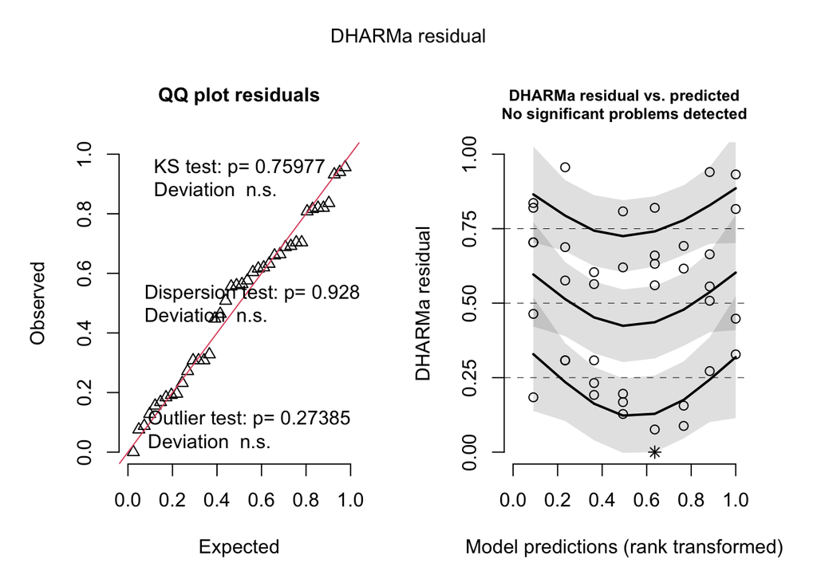

```r
myo.diff.mod2 <- lmer(deltacq ~ condition + day + (1 | trial), data = myo.diff)
myo.diff.res2 <- simulateResiduals(myo.diff.mod2)
plot(myo.diff.res2)
```

```r
AIC(myo.diff.mod, myo.diff.mod2) # effectively equal
```

|  | df | AIC |
| --- | --- | --- |
| myo.diff.mod | 10 | 128.4604 |
| myo.diff.mod2 | 7 | 130.3809 |

```r
summary(myo.diff.mod2)
```

```
## Linear mixed model fit by REML. t-tests use Satterthwaite's method [
## lmerModLmerTest]
## Formula: deltacq ~ condition + day + (1 | trial)
##    Data: myo.diff
##
## REML criterion at convergence: 116.4
##
## Scaled residuals:
##     Min      1Q  Median      3Q     Max
## -2.1216 -0.5686  0.1771  0.5145  1.7305
##
## Random effects:
##  Groups   Name        Variance Std.Dev.
##  trial    (Intercept) 1.3345   1.1552
##  Residual             0.8328   0.9126
## Number of obs: 40, groups:  trial, 6
##
## Fixed effects:
##               Estimate Std. Error      df t value Pr(>|t|)
## (Intercept)     5.9691     0.5595  8.0336  10.668 5.06e-06 ***
## condition10HS   2.1818     0.4118 30.3797   5.298 9.69e-06 ***
## condition2FBS   1.6936     0.4099 30.2447   4.131 0.000263 ***
## condition2HS    1.8800     0.3986 30.3654   4.716 5.05e-05 ***
## day2           -2.6260     0.2915 30.0945  -9.009 4.77e-10 ***
## ---
## Signif. codes:  0 '***' 0.001 '**' 0.01 '*' 0.05 '.' 0.1 ' ' 1
##
## Correlation of Fixed Effects:
##             (Intr) cn10HS cn2FBS cnd2HS
## conditn10HS -0.289
## conditn2FBS -0.290  0.401
## conditin2HS -0.312  0.460  0.409
## day2        -0.260 -0.045 -0.047  0.004
```

Extracting estimated marginal means

```r
myo.cond.emmeans <- emmeans(myo.diff.mod2, pairwise ~ condition)
myo.cond.emmeans
```

```
## $emmeans
##  condition emmean    SE   df lower.CL upper.CL
##  10FBS       4.66 0.540 7.03     3.38     5.93
##  10HS        6.84 0.569 8.43     5.54     8.14
##  2FBS        6.35 0.567 8.38     5.05     7.65
##  2HS         6.54 0.559 7.92     5.24     7.83
##
## Results are averaged over the levels of: day
## Degrees-of-freedom method: kenward-roger
## Confidence level used: 0.95
##
## $contrasts
##  contrast     estimate    SE   df t.ratio p.value
##  10FBS - 10HS   -2.182 0.413 30.4  -5.283 <0.0001
##  10FBS - 2FBS   -1.694 0.411 30.2  -4.124  0.0015
##  10FBS - 2HS    -1.880 0.400 30.4  -4.704  0.0003
##  10HS - 2FBS     0.488 0.452 30.7   1.080  0.7041
##  10HS - 2HS      0.302 0.421 30.1   0.716  0.8898
##  2FBS - 2HS     -0.186 0.442 30.8  -0.421  0.9744
##
## Results are averaged over the levels of: day
## Degrees-of-freedom method: kenward-roger
## P value adjustment: tukey method for comparing a family of 4 estimates
```

```r
myo.day.emmeans <- emmeans(myo.diff.mod2, pairwise ~ day)
myo.day.emmeans
```

```
## $emmeans
##  day emmean    SE   df lower.CL upper.CL
##  1     7.41 0.519 5.98     6.14     8.68
##  2     4.78 0.514 5.75     3.51     6.05
##
## Results are averaged over the levels of: condition
## Degrees-of-freedom method: kenward-roger
## Confidence level used: 0.95
##
## $contrasts
##  contrast    estimate    SE   df t.ratio p.value
##  day1 - day2     2.63 0.292 30.1   9.003 <0.0001
##
## Results are averaged over the levels of: condition
## Degrees-of-freedom method: kenward-roger
```

### *Visualization*

Colour palette for MB, Day 1, Day 2 NB: can convert all colour palettes to a colourblind or grey scale friendly palette

```r
day.cols <- pnw_palette(name = "Starfish", n = 3, type = "discrete")
```

Myogenin expression

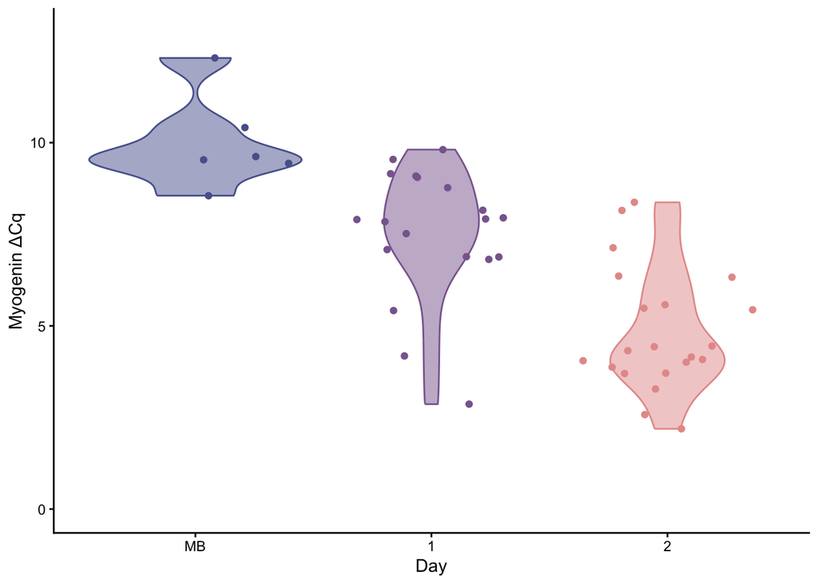

```r
ggplot(myo, aes(x = day, y = deltacq, fill = day, colour = day)) +
  geom_jitter() +
  geom_violin(alpha = 0.5) +
  scale_color_manual(values = day.cols) +
  scale_fill_manual(values = day.cols) +
  theme_classic() +
  labs(x = "Day", y = "Myogenin ΔCq") +
  theme(legend.position = "none") +
  coord_cartesian(ylim = c(0, 13))
```

## **p21 Expression**

### *Modelling*

```r
p21.mod <- lmer(deltacq ~ condition*day + (1|trial), data = p21)
```

```
## fixed-effect model matrix is rank deficient so dropping 3 columns / coefficients
```

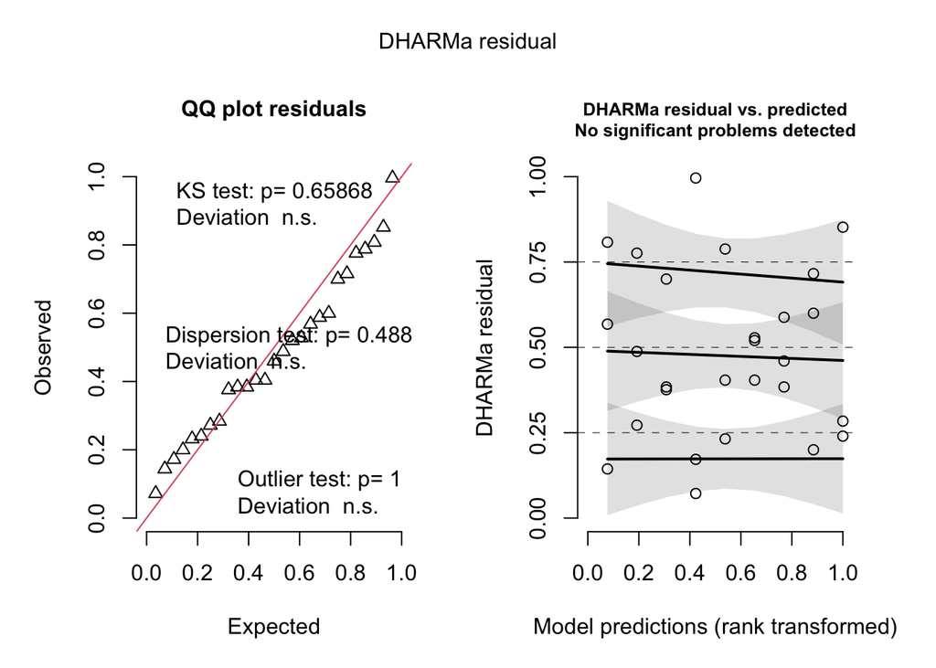

```r
p21.res <- simulateResiduals(p21.mod)
plot(p21.res)
```

```r
summary(p21.mod)
```

```
## Linear mixed model fit by REML. t-tests use Satterthwaite's method [
## lmerModLmerTest]
## Formula: deltacq ~ condition * day + (1 | trial)
##    Data: p21
##
## REML criterion at convergence: 55.6
##
## Scaled residuals:
##      Min       1Q   Median       3Q      Max
## -1.47443 -0.49968 -0.05923  0.45443  2.46269
##
## Random effects:
##  Groups   Name        Variance Std.Dev.
##  trial    (Intercept) 0.1444   0.380
##  Residual             0.6578   0.811
## Number of obs: 27, groups:  trial, 3
##
## Fixed effects:
##                    Estimate Std. Error      df t value Pr(>|t|)
## (Intercept)          6.3278     0.5171 14.2945  12.237 5.75e-09 ***
## condition10HS       -0.2000     0.6622 16.0000  -0.302   0.7665
## condition2FBS       -0.5800     0.6622 16.0000  -0.876   0.3941
## condition2HS        -0.5400     0.6622 16.0000  -0.815   0.4268
## day1                -1.1683     0.6622 16.0000  -1.764   0.0968 .
## day2                -1.3378     0.6622 16.0000  -2.020   0.0604 .
## condition10HS:day1   0.4339     0.9365 16.0000   0.463   0.6494
## condition2FBS:day1   0.7794     0.9365 16.0000   0.832   0.4175
## condition2HS:day1    0.6406     0.9365 16.0000   0.684   0.5038
## ---
## Signif. codes:  0 '***' 0.001 '**' 0.01 '*' 0.05 '.' 0.1 ' ' 1
##
## Correlation of Fixed Effects:
##             (Intr) cn10HS cn2FBS cnd2HS day1   day2   c10HS: c2FBS:
## conditn10HS  0.000
## conditn2FBS  0.000  0.500
## conditin2HS  0.000  0.500  0.500
## day1        -0.640  0.000  0.000  0.000
## day2        -0.640 -0.500 -0.500 -0.500  0.500
## cndtn10HS:1  0.000 -0.707 -0.354 -0.354 -0.354  0.354
## cndtn2FBS:1  0.000 -0.354 -0.707 -0.354 -0.354  0.354  0.500
## cndtn2HS:d1  0.000 -0.354 -0.354 -0.707 -0.354  0.354  0.500  0.500
## fit warnings:
## fixed-effect model matrix is rank deficient so dropping 3 columns / coefficients
```

Rank deficient again, so dropping day MB

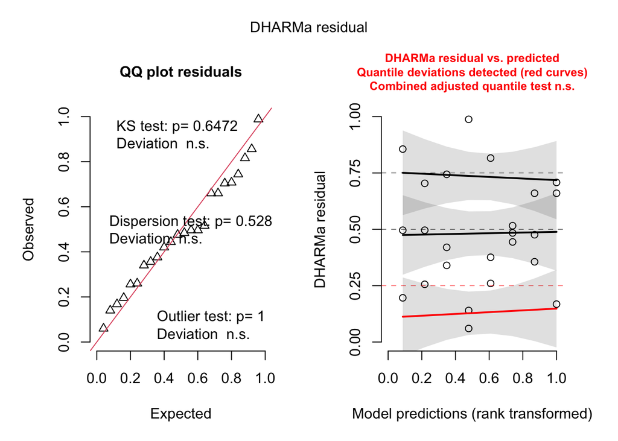

```r
p21.diff <- p21 %>%
  filter(day == "1" | day == "2")

p21.diff.mod <- lmer(deltacq ~ condition * day + (1 | trial), data = p21.diff)
p21.diff.res <- simulateResiduals(p21.diff.mod)
plot(p21.diff.res) # sig issues with quantile test
```

```r
summary(p21.diff.mod)
```

```
## Linear mixed model fit by REML. t-tests use Satterthwaite's method [
## lmerModLmerTest]
## Formula: deltacq ~ condition * day + (1 | trial)
##    Data: p21.diff
##
## REML criterion at convergence: 49.3
##
## Scaled residuals:
##      Min       1Q   Median       3Q      Max
## -1.50591 -0.50279 -0.04523  0.46477  2.41316
##
## Random effects:
##  Groups   Name        Variance Std.Dev.
##  trial    (Intercept) 0.1743   0.4175
##  Residual             0.6349   0.7968
## Number of obs: 24, groups:  trial, 3
##
## Fixed effects:
##                    Estimate Std. Error      df t value Pr(>|t|)
## (Intercept)          5.1594     0.5194 12.0785   9.934 3.64e-07 ***
## condition10HS        0.2339     0.6506 14.0000   0.359    0.725
## condition2FBS        0.1994     0.6506 14.0000   0.307    0.764
## condition2HS         0.1006     0.6506 14.0000   0.155    0.879
## day2                -0.1694     0.6506 14.0000  -0.260    0.798
## condition10HS:day2  -0.4339     0.9201 14.0000  -0.472    0.644
## condition2FBS:day2  -0.7794     0.9201 14.0000  -0.847    0.411
## condition2HS:day2   -0.6406     0.9201 14.0000  -0.696    0.498
## ---
## Signif. codes:  0 '***' 0.001 '**' 0.01 '*' 0.05 '.' 0.1 ' ' 1
##
## Correlation of Fixed Effects:
##             (Intr) cn10HS cn2FBS cnd2HS day2   c10HS: c2FBS:
## conditn10HS -0.626
## conditn2FBS -0.626  0.500
## conditin2HS -0.626  0.500  0.500
## day2        -0.626  0.500  0.500  0.500
## cndtn10HS:2  0.443 -0.707 -0.354 -0.354 -0.707
## cndtn2FBS:2  0.443 -0.354 -0.707 -0.354 -0.707  0.500
## cndtn2HS:d2  0.443 -0.354 -0.354 -0.707 -0.707  0.500  0.500
```

- Intercept: Represents the baseline predicted `deltacq` for 10FBS at Day 1.
- Condition main effects (day 1): None of the media conditions differ significantly from the 10FBS baseline on Day 1.
- Time main effect (day2): `deltacq` does not change significantly between Day 1 and Day 2 within 10FBS.
- Condition * Day interactions: None of the interaction terms are significant.

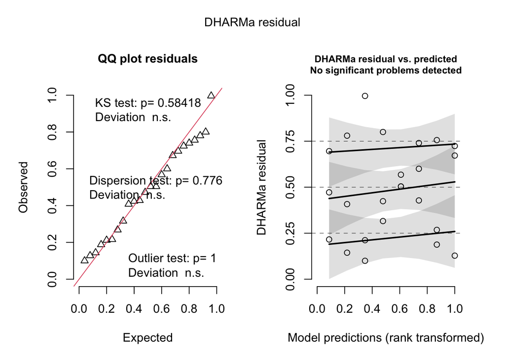

```r
p21.noint.mod <- lmer(deltacq ~ condition + day + (1 | trial), data = p21.diff)
noint.res <- simulateResiduals(p21.noint.mod)
plot(noint.res) # no issues
```

```r
summary(p21.noint.mod)
```

```
## Linear mixed model fit by REML. t-tests use Satterthwaite's method [
## lmerModLmerTest]
## Formula: deltacq ~ condition + day + (1 | trial)
##    Data: p21.diff
##
## REML criterion at convergence: 54.2
##
## Scaled residuals:
##     Min      1Q  Median      3Q     Max
## -1.2763 -0.6626 -0.0607  0.5182  2.8673
##
## Random effects:
##  Groups   Name        Variance Std.Dev.
##  trial    (Intercept) 0.1844   0.4295
##  Residual             0.5535   0.7440
## Number of obs: 24, groups:  trial, 3
##
## Fixed effects:
##               Estimate Std. Error       df t value Pr(>|t|)
## (Intercept)    5.39118    0.42046  7.67112  12.822 1.87e-06 ***
## condition10HS  0.01694    0.42953 17.00000   0.039   0.9690
## condition2FBS -0.19028    0.42953 17.00000  -0.443   0.6634
## condition2HS  -0.21972    0.42953 17.00000  -0.512   0.6155
## day2          -0.63292    0.30372 17.00000  -2.084   0.0526 .
## ---
## Signif. codes:  0 '***' 0.001 '**' 0.01 '*' 0.05 '.' 0.1 ' ' 1
##
## Correlation of Fixed Effects:
##             (Intr) cn10HS cn2FBS cnd2HS
## conditn10HS -0.511
## conditn2FBS -0.511  0.500
## conditin2HS -0.511  0.500  0.500
## day2        -0.361  0.000  0.000  0.000
```

- Intercept: Represents the baseline predicted `deltacq` for 10FBS at Day 1.
  - Condition effects (averaged across days): No significant differences exist between conditions
  - Time Effect (averaged across conditions): decrease in `deltacq` on day 2 relative to day 1, but not significant (p = 0.0526)

Extracting estimated marginal means:

```r
p21.cond.emmeans <- emmeans(p21.noint.mod, pairwise ~ condition)
p21.cond.emmeans
```

```
## $emmeans
##  condition emmean    SE   df lower.CL upper.CL
##  10FBS       5.07 0.392 6.13     4.12     6.03
##  10HS        5.09 0.392 6.13     4.14     6.05
##  2FBS        4.88 0.392 6.13     3.93     5.84
##  2HS         4.86 0.392 6.13     3.90     5.81
##
## Results are averaged over the levels of: day
## Degrees-of-freedom method: kenward-roger
## Confidence level used: 0.95
##
## $contrasts
##  contrast     estimate   SE df t.ratio p.value
##  10FBS - 10HS  -0.0169 0.43 17  -0.039  1.0000
##  10FBS - 2FBS   0.1903 0.43 17   0.443  0.9701
##  10FBS - 2HS    0.2197 0.43 17   0.512  0.9552
##  10HS - 2FBS    0.2072 0.43 17   0.482  0.9620
##  10HS - 2HS     0.2367 0.43 17   0.551  0.9450
##  2FBS - 2HS     0.0294 0.43 17   0.069  0.9999
##
## Results are averaged over the levels of: day
## Degrees-of-freedom method: kenward-roger
## P value adjustment: tukey method for comparing a family of 4 estimates
```

```r
p21.day.emmeans <- emmeans(p21.noint.mod, pairwise ~ day)
p21.day.emmeans
```

```
## $emmeans
##  day emmean    SE   df lower.CL upper.CL
##  1     5.29 0.328 3.21     4.29     6.30
##  2     4.66 0.328 3.21     3.65     5.67
##
## Results are averaged over the levels of: condition
## Degrees-of-freedom method: kenward-roger
## Confidence level used: 0.95
##
## $contrasts
##  contrast    estimate    SE df t.ratio p.value
##  day1 - day2    0.633 0.304 17   2.084  0.0526
##
## Results are averaged over the levels of: condition
## Degrees-of-freedom method: kenward-roger
```

### *Visualization*

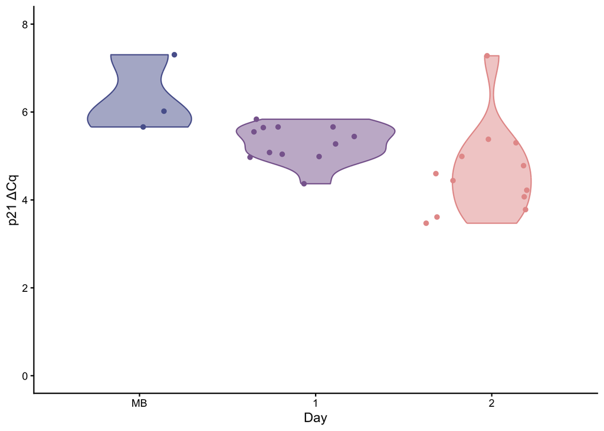

```r
ggplot(p21, aes(x = day, y = deltacq, fill = day, colour = day)) +
  geom_jitter() +
  geom_violin(alpha = 0.5) +
  scale_color_manual(values = day.cols) +
  scale_fill_manual(values = day.cols) +
  theme_classic() +
  labs(x = "Day", y = "p21 ΔCq") +
  theme(legend.position = "none") +
  coord_cartesian(ylim = c(0, 8))
```

## **Cell Fusion Index**

### *Modelling*

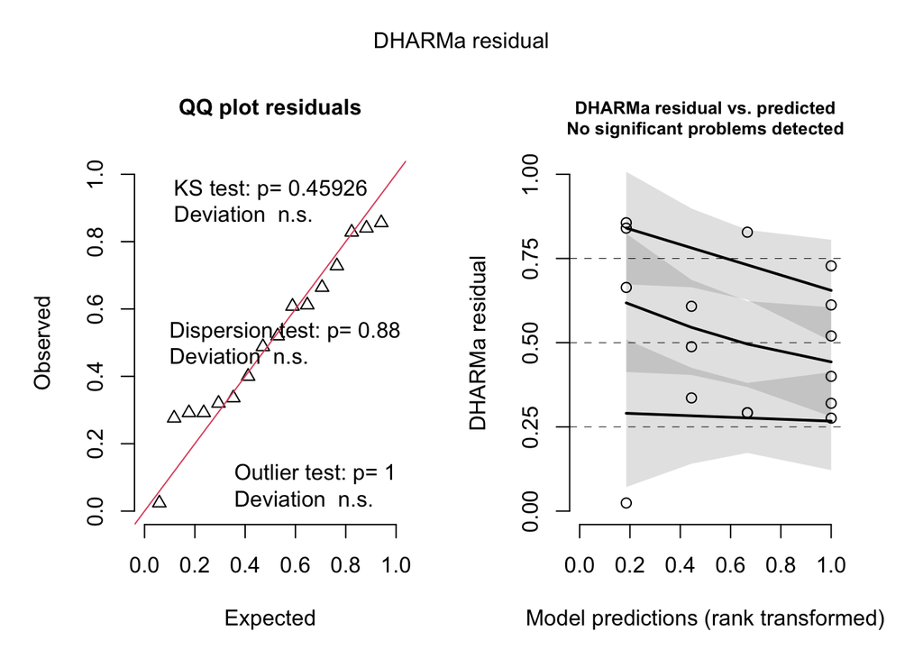

```r
cfi.mod <- lmer(cfi ~ condition + (1|trial), data = cfi)
cfi.res <- simulateResiduals(cfi.mod)
plot(cfi.res)
```

```r
summary(cfi.mod)
```

```
## Linear mixed model fit by REML. t-tests use Satterthwaite's method [
## lmerModLmerTest]
## Formula: cfi ~ condition + (1 | trial)
##    Data: cfi
##
## REML criterion at convergence: 83.5
##
## Scaled residuals:
##     Min      1Q  Median      3Q     Max
## -2.2057 -0.3666  0.1103  0.4269  1.0455
##
## Random effects:
##  Groups   Name        Variance Std.Dev.
##  trial    (Intercept) 12.36    3.515
##  Residual             29.50    5.431
## Number of obs: 16, groups:  trial, 6
##
## Fixed effects:
##               Estimate Std. Error     df t value Pr(>|t|)
## (Intercept)     59.884      3.630 11.974  16.498 1.34e-09 ***
## condition10HS   -1.030      4.209  8.242  -0.245    0.813
## condition2FBS   39.524      4.979 11.216   7.938 6.23e-06 ***
## condition2HS    40.116      4.004  9.229  10.019 2.91e-06 ***
## ---
## Signif. codes:  0 '***' 0.001 '**' 0.01 '*' 0.05 '.' 0.1 ' ' 1
##
## Correlation of Fixed Effects:
##             (Intr) cn10HS cn2FBS
## conditn10HS -0.681
## conditn2FBS -0.686  0.524
## conditin2HS -0.765  0.618  0.622
```

```r
cfi.emm <- emmeans(cfi.mod, pairwise ~ condition)
summary(cfi.emm)
```

```
## $emmeans
##  condition emmean   SE   df lower.CL upper.CL
##  10FBS       59.9 3.85 12.0     51.5     68.3
##  10HS        58.9 3.30 11.7     51.6     66.1
##  2FBS        99.4 3.85 12.0     91.0    107.8
##  2HS        100.0 2.64 10.6     94.2    105.8
##
## Degrees-of-freedom method: kenward-roger
## Confidence level used: 0.95
##
## $contrasts
##  contrast     estimate   SE    df t.ratio p.value
##  10FBS - 10HS    1.030 4.29  7.54   0.240  0.9947
##  10FBS - 2FBS  -39.524 5.59 11.00  -7.072  0.0001
##  10FBS - 2HS   -40.116 4.20  8.64  -9.551 <0.0001
##  10HS - 2FBS   -40.554 4.97 10.34  -8.161 <0.0001
##  10HS - 2HS    -41.146 3.71  8.05 -11.101 <0.0001
##  2FBS - 2HS     -0.592 4.20  8.64  -0.141  0.9989
##
## Degrees-of-freedom method: kenward-roger
## P value adjustment: tukey method for comparing a family of 4 estimates
```

### *Visualization*

Colour palette for conditions (10FBS, 10HS, 2FBS, 2HS)

```r
cond.cols <- pnw_palette(name = "Sunset", n = 4, type = "discrete")
```

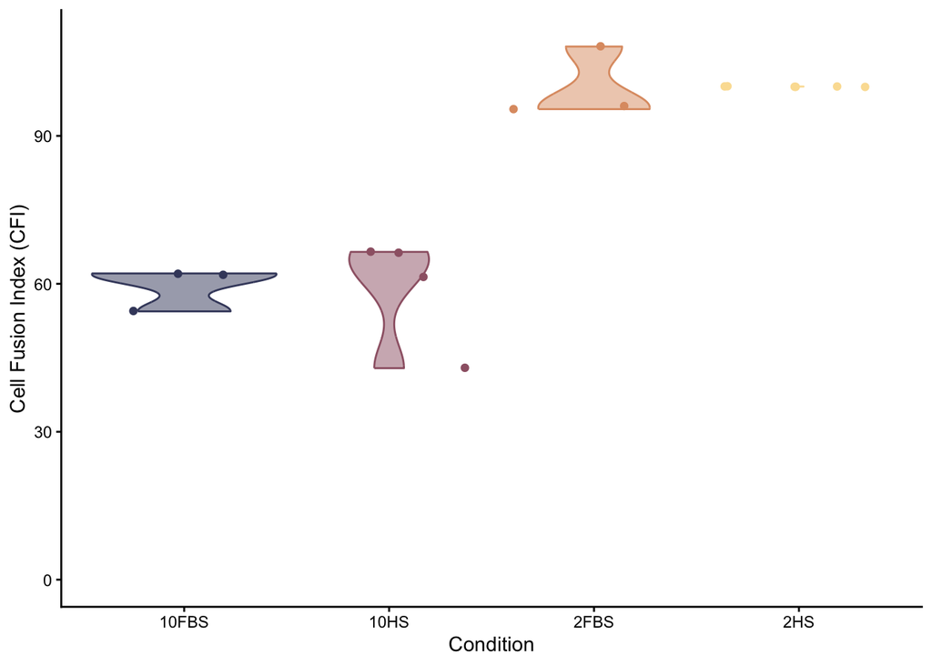

```r
ggplot(cfi, aes(x = condition, y = cfi, fill = condition, colour = condition)) +
  geom_jitter() +
  geom_violin(alpha = 0.5) +
  scale_color_manual(values = cond.cols) +
  scale_fill_manual(values = cond.cols) +
  theme_classic() +
  labs(x = "Condition", y = "Cell Fusion Index (CFI)") +
  theme(legend.position = "none") +
  coord_cartesian(ylim = c(0, 110))
```

Note: this x-axis can be rearranged depending on what order you want the conditions to be presented in

## **Myotube Diameter**

### *Modelling*

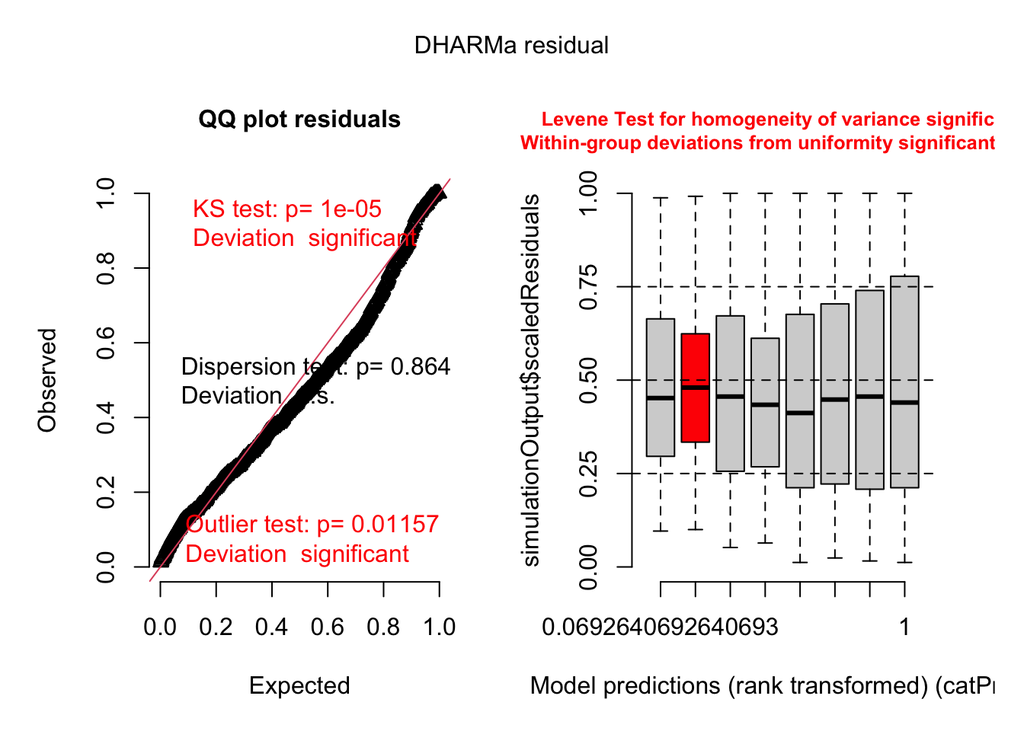

```r
diam.lmod <- lmer(diameter ~ condition*day + (1|trial), data = diam)
diam.lres <- simulateResiduals(diam.lmod)
plot(diam.lres) # lots of issues
```

### *Distribution fitting*

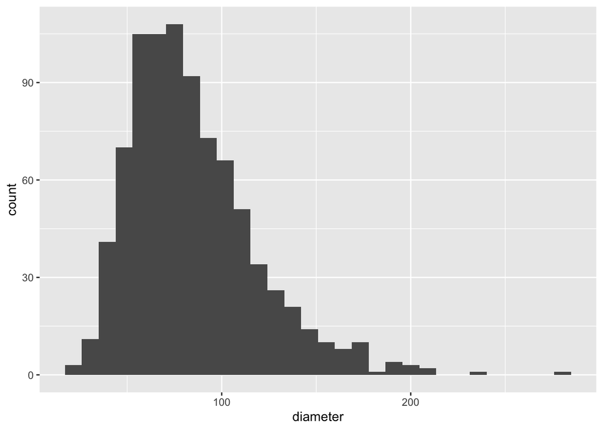

```r
ggplot(diam, aes(x = diameter)) +
  geom_histogram() # looks gamma-y
```

```r
fit.gamma <- fitdist(diam$diameter, "gamma")
fit.lnorm <- fitdist(diam$diameter, "lnorm")
fit.norm <- fitdist(diam$diameter, "norm")
```

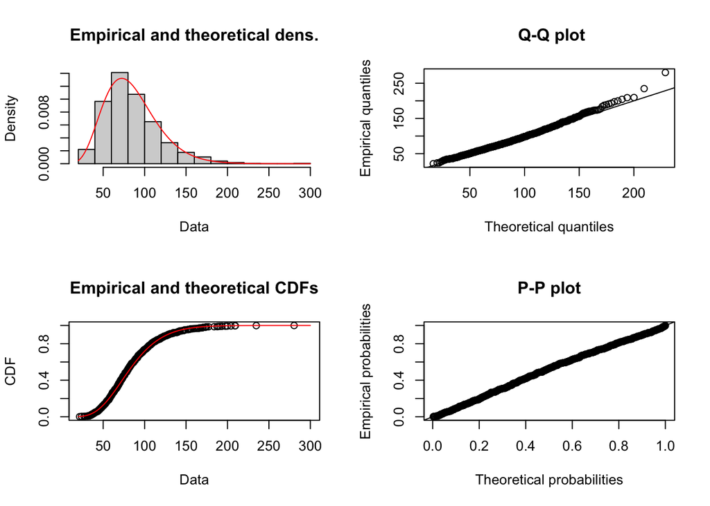

```r
plot(fit.gamma)
```

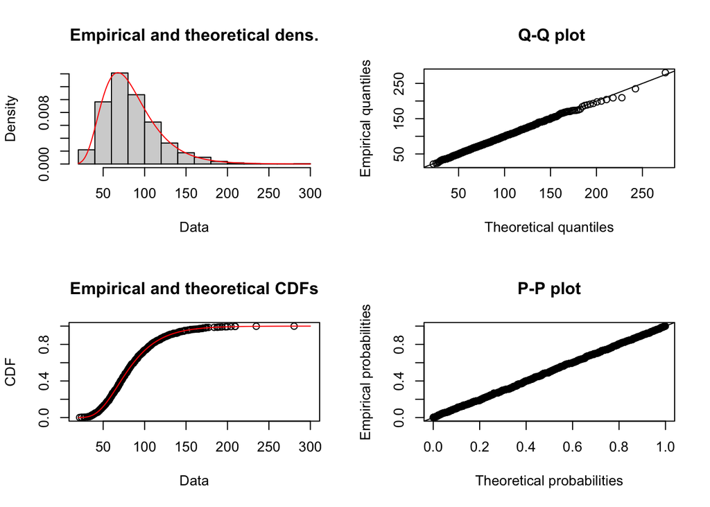

```r
plot(fit.lnorm)
```

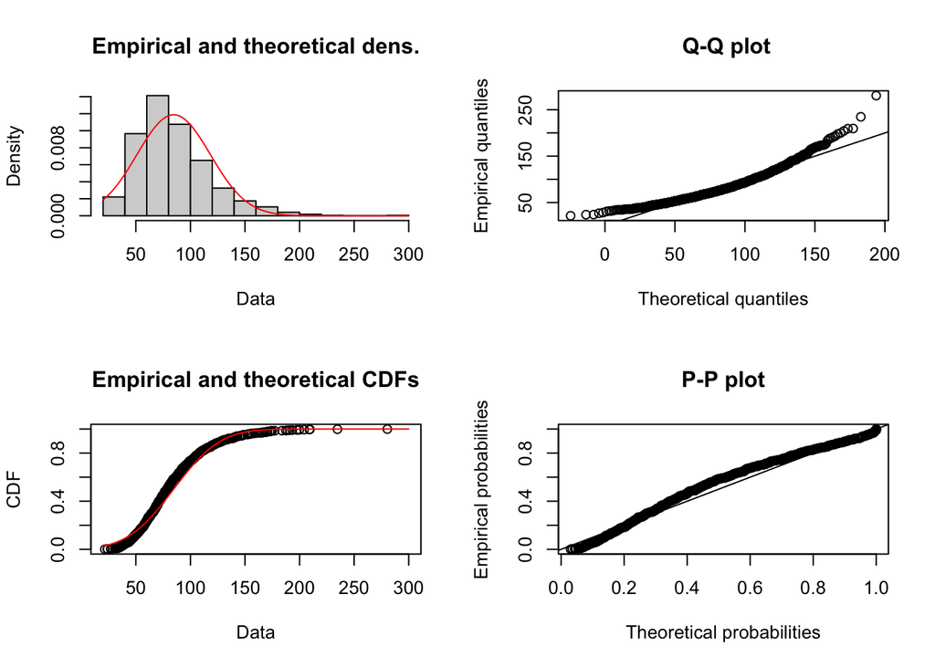

```r
plot(fit.norm)
```

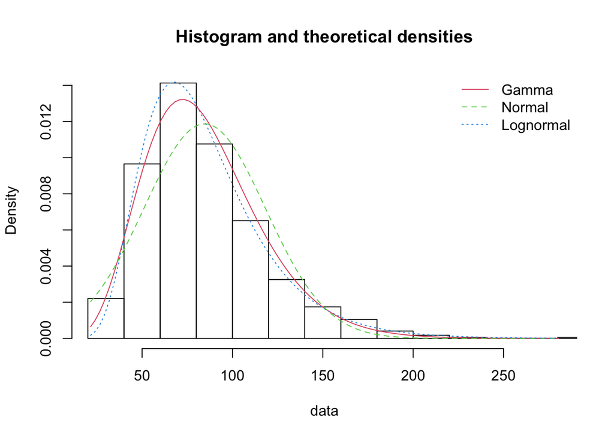

```r
denscomp(list(fit.gamma, fit.norm, fit.lnorm), legendtext = c("Gamma", "Normal", "Lognormal"))
```

```r
gofstat(list(fit.norm, fit.gamma, fit.lnorm))$aic
```

```
##  1-mle-norm 2-mle-gamma 3-mle-lnorm
##    8489.909    8328.717    8311.932
```

```r
#lognormal it is
```

### *Modelling*

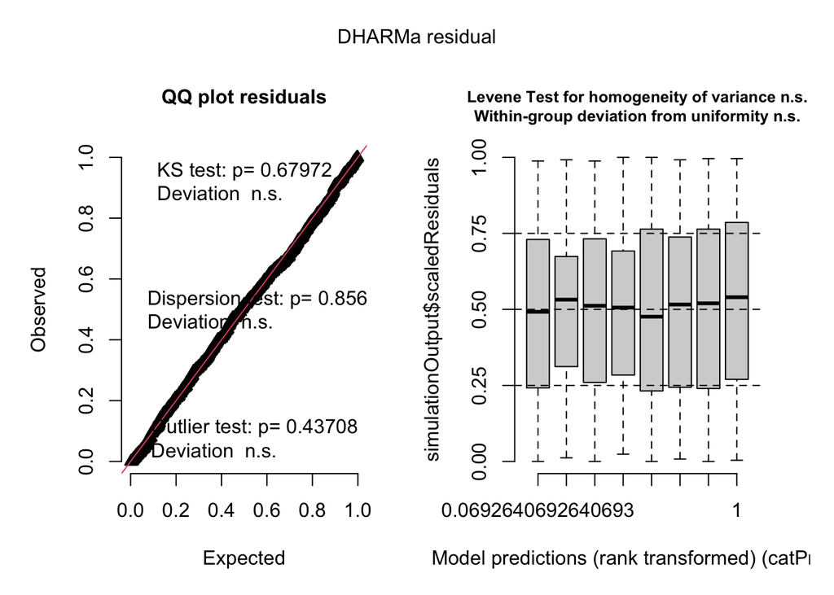

```r
diam.mod <- lmer(log(diameter) ~ condition * day + (1|trial), data = diam)
diam.res <- simulateResiduals(diam.mod)
plot(diam.res)
```

```r
summary(diam.mod)
```

```
## Linear mixed model fit by REML. t-tests use Satterthwaite's method [
## lmerModLmerTest]
## Formula: log(diameter) ~ condition * day + (1 | trial)
##    Data: diam
##
## REML criterion at convergence: 705.4
##
## Scaled residuals:
##     Min      1Q  Median      3Q     Max
## -3.7207 -0.6298  0.0447  0.6229  3.4883
##
## Random effects:
##  Groups   Name        Variance Std.Dev.
##  trial    (Intercept) 0.002317 0.04813
##  Residual             0.127699 0.35735
## Number of obs: 860, groups:  trial, 3
##
## Fixed effects:
##                      Estimate Std. Error        df t value Pr(>|t|)
## (Intercept)           4.42289    0.04350   8.30048 101.670 3.82e-14 ***
## condition10HS         0.10340    0.05040 850.07025   2.052   0.0405 *
## condition2FBS        -0.20293    0.04614 850.40459  -4.398 1.23e-05 ***
## condition2HS          0.08564    0.04811 850.14551   1.780   0.0754 .
## day12                -0.29187    0.04767 850.20328  -6.123 1.40e-09 ***
## condition10HS:day12   0.03709    0.07039 849.99518   0.527   0.5983
## condition2FBS:day12   0.43333    0.06695 850.09362   6.472 1.63e-10 ***
## condition2HS:day12    0.32713    0.06850 850.00962   4.776 2.11e-06 ***
## ---
## Signif. codes:  0 '***' 0.001 '**' 0.01 '*' 0.05 '.' 0.1 ' ' 1
##
## Correlation of Fixed Effects:
##             (Intr) cn10HS cn2FBS cnd2HS day12  c10HS: c2FBS:
## conditn10HS -0.511
## conditn2FBS -0.558  0.481
## conditin2HS -0.535  0.462  0.504
## day12       -0.540  0.467  0.508  0.489
## cndt10HS:12  0.366 -0.716 -0.345 -0.331 -0.677
## cndt2FBS:12  0.385 -0.332 -0.689 -0.347 -0.711  0.482
## cndtn2HS:12  0.376 -0.325 -0.354 -0.702 -0.696  0.471  0.495
```

- Intercept: Represents the baseline predicted `diameter` for 10FBS at Day 7. Untransformed, is e^4.43 ~= 83.3 mu (microns).
- Condition main effects (compared to 10FBS on day 7): myotubes in 10HS are significantly larger in diameter, and myotubes in 2FBS are significantly smaller in diameter.
- Time main effect (10FBS over time): myotubes in 10FBS significantly decrease in diameter by day 12
- Condition * Day interactions (differences between day 7 & day 12):
  - myotubes in 2FBS & 2HS show significant increase in diameter
  - myotubes in 10HS do not differ in behaviour significantly from 10FBS. Since myotubes in 10FBS significantly decrease between day 7 and day 12 (see Time main effect above), so to do mytoubes in 10HS

Extracting simple main effects:

```r
diam.emmeans <- emmeans(diam.mod, pairwise ~ condition | day)
diam.emmeans
```

```
## $emmeans
## day = 7:
##  condition emmean     SE    df lower.CL upper.CL
##  10FBS       4.42 0.0435  8.40     4.32     4.52
##  10HS        4.53 0.0468 11.25     4.42     4.63
##  2FBS        4.22 0.0422  7.44     4.12     4.32
##  2HS         4.51 0.0444  9.07     4.41     4.61
##
## day = 12:
##  condition emmean     SE    df lower.CL upper.CL
##  10FBS       4.13 0.0439  8.68     4.03     4.23
##  10HS        4.27 0.0452  9.75     4.17     4.37
##  2FBS        4.36 0.0445  9.17     4.26     4.46
##  2HS         4.54 0.0448  9.39     4.44     4.64
##
## Degrees-of-freedom method: kenward-roger
## Results are given on the log (not the response) scale.
## Confidence level used: 0.95
##
## $contrasts
## day = 7:
##  contrast     estimate     SE  df t.ratio p.value
##  10FBS - 10HS  -0.1034 0.0504 850  -2.052  0.1701
##  10FBS - 2FBS   0.2029 0.0461 850   4.397 <0.0001
##  10FBS - 2HS   -0.0856 0.0481 850  -1.780  0.2837
##  10HS - 2FBS    0.3063 0.0493 851   6.210 <0.0001
##  10HS - 2HS     0.0178 0.0511 850   0.347  0.9856
##  2FBS - 2HS    -0.2886 0.0470 851  -6.142 <0.0001
##
## day = 12:
##  contrast     estimate     SE  df t.ratio p.value
##  10FBS - 10HS  -0.1405 0.0491 850  -2.859  0.0226
##  10FBS - 2FBS  -0.2304 0.0485 850  -4.747 <0.0001
##  10FBS - 2HS   -0.4128 0.0488 850  -8.464 <0.0001
##  10HS - 2FBS   -0.0899 0.0497 850  -1.809  0.2699
##  10HS - 2HS    -0.2723 0.0499 850  -5.454 <0.0001
##  2FBS - 2HS    -0.1824 0.0493 850  -3.697  0.0013
##
## Degrees-of-freedom method: kenward-roger
## Results are given on the log (not the response) scale.
## P value adjustment: tukey method for comparing a family of 4 estimates
```

### *Visualization*

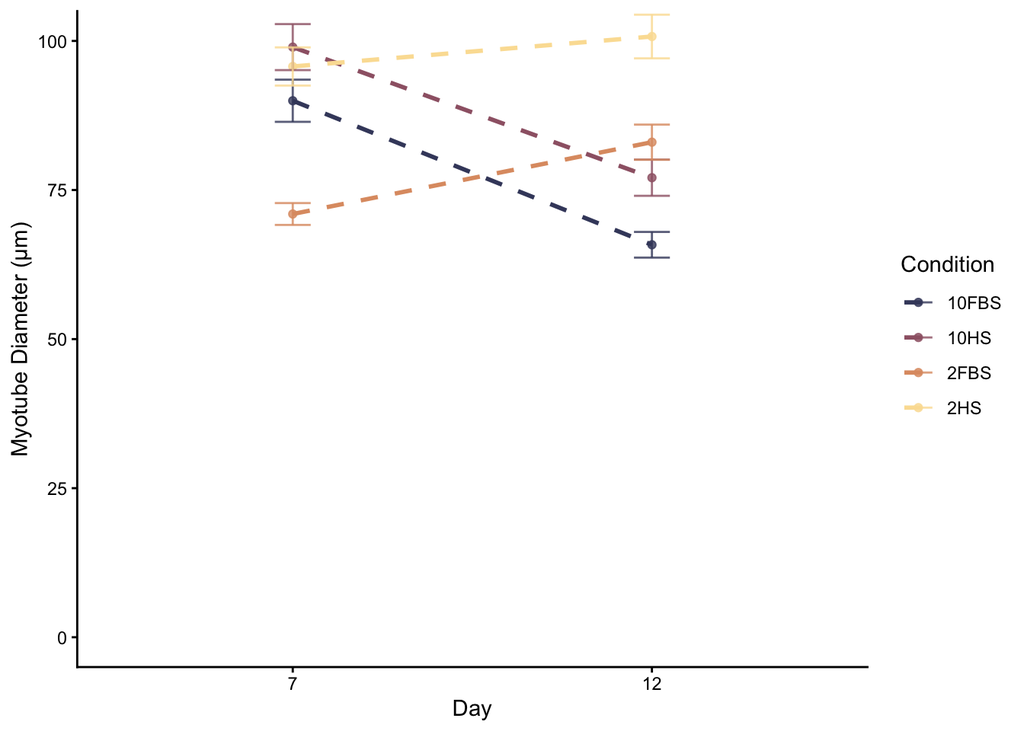

```r
ggplot(diam, aes(x = day, y = diameter, colour = condition, fill = condition)) +
  stat_summary(fun = mean, geom = "point", alpha = 0.8) +
  stat_summary(fun = mean, geom = "line", aes(group = condition), linewidth = 1, lty = 2) +
  stat_summary(fun.data = mean_se, geom = "errorbar", width = 0.1, alpha = 0.8) +
  scale_colour_manual(values = cond.cols) +
  scale_fill_manual(values = cond.cols) +
  theme_classic() +
  labs(x = "Day", y = "Myotube Diameter (μm)", colour = "Condition", fill = "Condition") +
  coord_cartesian(ylim = c(0, 100))
```